# Plotting Answer 1

MRC LMS

19/09/2019

These exercises cover the sections of Plotting in R [PlottingInR](https://lmsbioinformatics.github.io/LMS_PlottingInR/course/PlotInR.html).

## Exercise 1

Please load the dateset **mtcars** by calling data(mtcars) and use the base R graphics to

1. create a scatter plot of mtcars$mpg VS mtcars$wt (x-axis = mpg and y-axis = wt).
2. change the labels for x axis = “Miles/(US) gallon” and y axis = “Weight (1000 lbs)”
3. add title = “scatter plot”
4. change the colour of points to red and the the shape of points to “filled circle”

[hint: use data() function to load mtcars]

```r
data(mtcars)
head(mtcars)
```

```
##                    mpg cyl disp  hp drat    wt  qsec vs am gear carb
## Mazda RX4         21.0   6  160 110 3.90 2.620 16.46  0  1    4    4
## Mazda RX4 Wag     21.0   6  160 110 3.90 2.875 17.02  0  1    4    4
## Datsun 710        22.8   4  108  93 3.85 2.320 18.61  1  1    4    1
## Hornet 4 Drive    21.4   6  258 110 3.08 3.215 19.44  1  0    3    1
## Hornet Sportabout 18.7   8  360 175 3.15 3.440 17.02  0  0    3    2
## Valiant           18.1   6  225 105 2.76 3.460 20.22  1  0    3    1
```

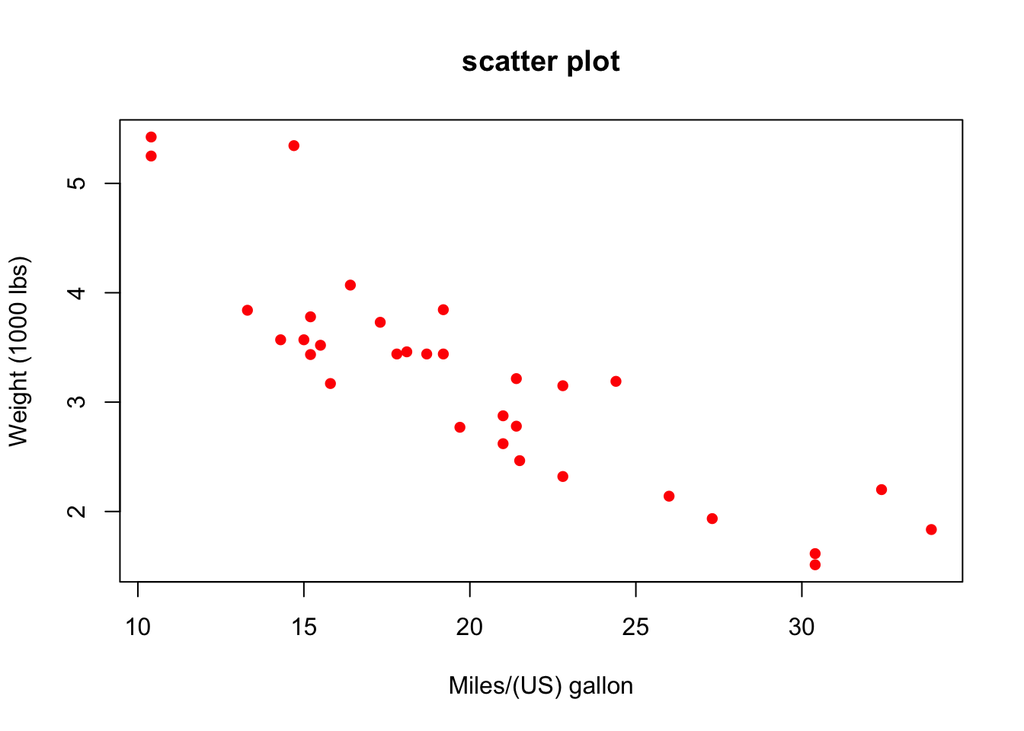

```r
plot(mtcars$mpg, mtcars$wt, main="scatter plot", xlab="Miles/(US) gallon", ylab="Weight (1000 lbs)",pch=16,col="red")
```

## Exercise 2

Please load the dateset **mtcars** by calling data(mtcars) and use the ggplot2 to

1. create a scatter plot of mtcars$mpg VS mtcars$wt (x-axis = mpg and y-axis = wt).
2. change the labels for x axis = “Miles/(US) gallon” and y axis = “Weight (1000 lbs)”
3. add title = “scatter plot”
4. change the colour of points to red [hint: use col=“red” when constructing aesthetic mappings]

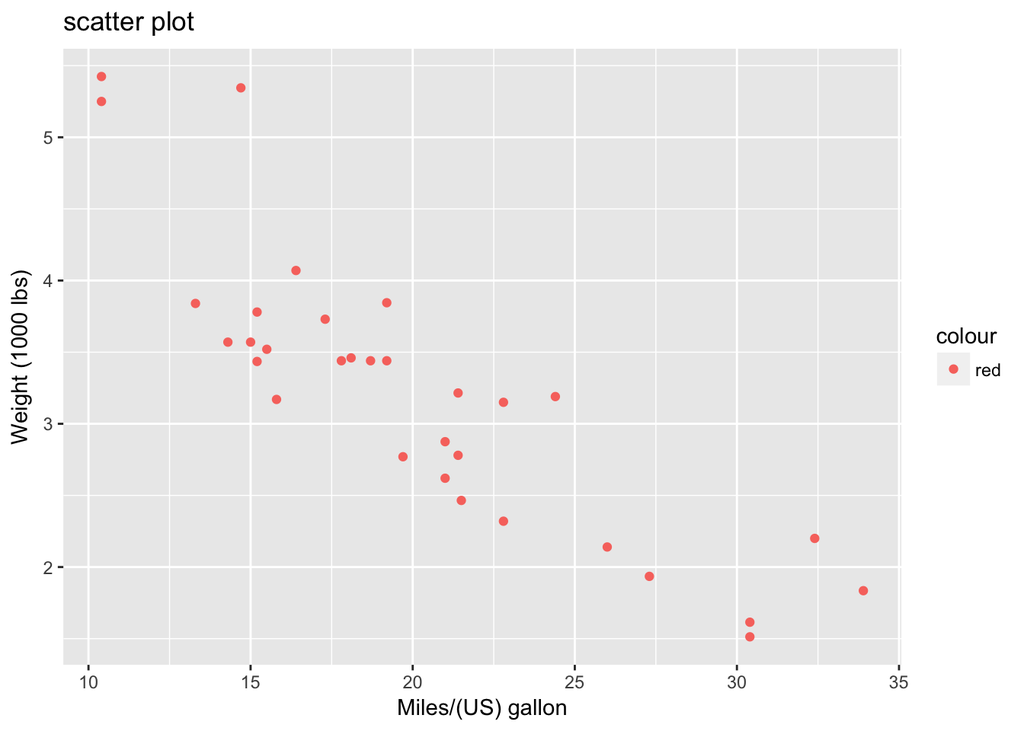

```r
library(ggplot2)
g<- ggplot(mtcars, aes(x=mpg,y=wt,col="red"))+ geom_point()

# option 1
g + labs(x="Miles/(US) gallon",y="Weight (1000 lbs)",title="scatter plot")

# option 2
g + xlab("Miles/(US) gallon")+ylab("Weight (1000 lbs)") +
  ggtitle=("scatter plot"))
```

5. 1. what will happen if change the colour of points to mtcars$am [hint: use col=am when constructing aesthetic mappings]

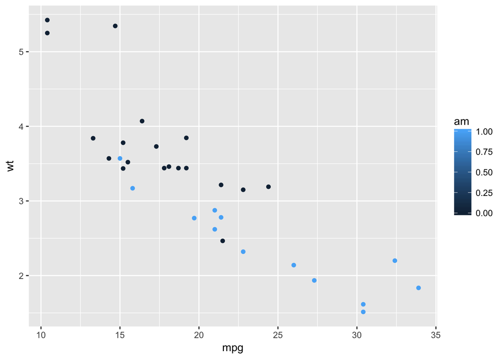

```r
library(ggplot2)
ggplot(mtcars, aes(x=mpg,y=wt,col=am))+ geom_point()
```

5. 2. what will happen if change the colour of points use col=as.factor(am) when constructing aesthetic mappings

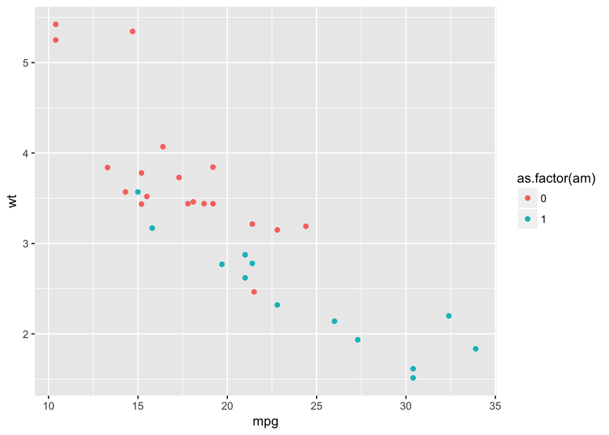

```r
library(ggplot2)
ggplot(mtcars, aes(x=mpg,y=wt,col=as.factor(am)))+ geom_point()
```